# Prediction Assignment for Machine Learning Course

Maiia Bakhova

August 23, 2015

## Human Activity Recognition

Read more: http://groupware.les.inf.puc-rio.br/har#ixzz3jfosRia6

**Data**

The training data for this project are available here:

https://d396qusza40orc.cloudfront.net/predmachlearn/pml-training.csv

The test data are available here:

https://d396qusza40orc.cloudfront.net/predmachlearn/pml-testing.csv

The data for this project come from this source: http://groupware.les.inf.puc-rio.br/har. If you use the document you create for this class for any purpose please cite them as they have been very generous in allowing their data to be used for this kind of assignment.

The goal of our project is to predict the manner in which they did the exercise. This is the “classe” variable in the training set. We may use any of the other variables to predict with.

We can load both data files and check the data. The last column “classe” contains letters which code the performance quality. I’ll start with loading packages I need.

```r
library(caret); library(e1071);library(randomForest); library(kernlab)
training=read.csv("pml-training.csv", stringsAsFactors=F)
testing=read.csv("pml-testing.csv", stringsAsFactors=F)
dim(training)
```

```
## [1] 19622   160
```

Now we can look at both files more closely. In particular, it is easy to establish that first columns contains names of subjects, days and times of recording and other classifiers which do not represent physical movements. For example the very first “X” column is used to enumerate rows.

```r
names(training)[1:10]
```

```
##  [1] "X"                    "user_name"            "raw_timestamp_part_1"
##  [4] "raw_timestamp_part_2" "cvtd_timestamp"       "new_window"
##  [7] "num_window"           "roll_belt"            "pitch_belt"
## [10] "yaw_belt"
```

```r
training$X[1:20]
```

```
##  [1]  1  2  3  4  5  6  7  8  9 10 11 12 13 14 15 16 17 18 19 20
```

Then we have users’ names and so on. They should be removed for a predicting model.

The next step is less obvious: by checking out the “testing” data I’ve discovered a lot of empty variables which have values in “training” data. Usually they are read as logical with nonexistent values and some as characters. We can check the amount of numeric variables in the test set and see that the number of meaningful predictors is fewer than 40%.

```r
sum(sapply(testing, is.numeric))
```

```
## [1] 57
```

To maintain the data consistency I will remove non numeric variables from both sets for my work. The new data sets with numeric predictors will be called “trai” and “test”, respectfully. In addition we need the “classe” variable to be treated as a factor.

```r
prVec=sapply(testing, is.numeric)
prVec[1:7]=F
trai=training[ , prVec]
test=testing[ , prVec]
```

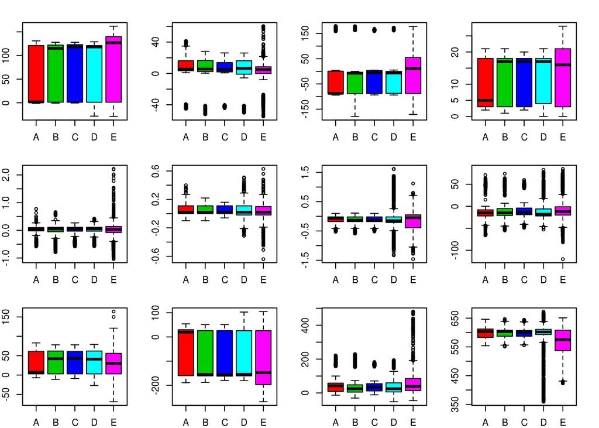

```r
par(mfrow=c(3,4), mar=c(2,2,2,2))
sapply(workTrai[, 1:12], function(x) boxplot(x~workTrai$classe, col=2:6) )
```

I wil not show other boxplots, since I’m not allowed to use more then 5 pictures, and the number of my pictures is questenable already.

From the observation of plots, it looks like the best variables are “magnet_belt_y” [12], “magnet_belt_z” [13], “gyros_arm_x” [18], “gyros_arm_y” [19], “accel_arm_x” [21], “magnet_arm_x” [24], “magnet_arm_y” [25], magnet_arm_z [26], “roll_dumbbell” [27], “magnet_dumbbell_x” [37], “magnet_dumbbell_y” [38], “roll_forearm” [40] and “accel_forearm_y” [48]. Gathering the predictors together with “classe” column:

```r
prefVec=c("magnet_belt_y",
"magnet_belt_z", "gyros_arm_x", "gyros_arm_y", "accel_arm_x",
"magnet_arm_x", "magnet_arm_y", "magnet_arm_z", "roll_dumbbell",
"magnet_dumbbell_x", "magnet_dumbbell_y", "roll_forearm",
"accel_forearm_y", "classe")
workdf=workTrai[ , prefVec]
workdf$classe=as.factor(workdf$classe)
 seed.set=7
modrf=train(classe~., data=workdf, method="rf")
```

```r
modrf
```

```
## Random Forest
##
## 13737 samples
##    13 predictors
##     5 classes: 'A', 'B', 'C', 'D', 'E'
##
## No pre-processing
## Resampling: Bootstrapped (25 reps)
## Summary of sample sizes: 13737, 13737, 13737, 13737, 13737, 13737, ...
## Resampling results across tuning parameters:
##
##   mtry  Accuracy   Kappa      Accuracy SD  Kappa SD
##    2    0.9481039  0.9342830  0.004231876  0.005381651
##    7    0.9427592  0.9275404  0.004514374  0.005735575
##   13    0.9326720  0.9147799  0.005015417  0.006371268
##
## Accuracy was used to select the optimal model using  the largest value.
## The final value used for the model was mtry = 2.
```

```r
valddf=valdTrai[, prefVec]
predictOnVald=predict(modrf, valddf[, -14])
print("Compare predictions on the validation set:")
```

```
## [1] "Compare predictions on the validation set:"
```

```r
table(valdTrai$classe, predictOnVald)
```

```
##    predictOnVald
##        A    B    C    D    E
##   A 1649    4   15    6    0
##   B   22 1082   28    5    2
##   C    3   19  998    2    4
##   D    9    5   45  900    5
##   E    2    9   10   12 1049
```

As we see on the model data and in the table, our precision is around 95%, which is quite good.